# Prosper Loan Data Exploration

## by Suresh Lokiah

# Investigation Overview

This exercise investigates the Prosper Loan [dataset](https://www.google.com/url?q=https://s3.amazonaws.com/udacity-hosted-downloads/ud651/prosperLoanData.csv&sa=D&ust=1554486256021000) through Visualization to find patterns and correlation of Loans, Borrower, Lender to maximize the LenderYield.

The dataset was methodically analyzed using a variety of plot types to explore different relationships in the dataset. The findings were documented as 'Notes' after each plot or analysis. Some of the analysis were further drilled-downed to explore patterns.

The goal of the analysis is

1. Evaluate the current scenario for Loans, Lenders
2. Provide insights to Lender for earning higher Yields.

(The resulting report in slides was peer-reviewed and improved).

# Dataset Overview

The Dataset conist of 113937 rows , 81 columns. The features in the dataset are organized as Loan Listing, Loan, Borrower Demographics, Borrower Credit Information, Investor and Loan ChargeOff.

# Univariate Exploration

## *Evaluating the Loan data =>*

### ListingCreationDate

Understand the distribution of loans across years.

```
Min = 2005-11-09 20:44:28.847000
Max = 2014-03-10 12:20:53.760000
```

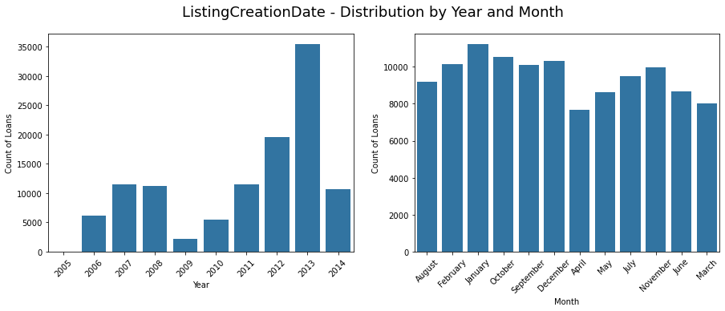

```python
#Convert to datetime datatype
df.ListingCreationDate = df.ListingCreationDate.astype('datetime64[ns]')

# Min and Max ListingCreationDate
print("Min = " + str(df.ListingCreationDate.min()) + "\nMax = " + str(df.ListingCreationDate.max()))

#Extract Year and Month of the listing
print()
df['yyyy'] = df.ListingCreationDate.dt.year
df['mmm'] = df.ListingCreationDate.dt.month_name()
print()

## Plot
plt.figure(figsize = [15, 5])
plt.suptitle('ListingCreationDate - Distribution by Year and Month', fontsize=18)

ax = plt.subplot(1, 2, 1)
sb.countplot(data=df, x='yyyy', label='By Year',color=sb.color_palette()[0]);
ax.set_xlabel("Year")
plt.xticks(rotation = 45)
plt.ylabel('Count of Loans');
#ax.set_xticklabels(xlabels, rotation=40, ha=ha[n])

ax = plt.subplot(1,2,2)
sb.countplot(data=df, x='mmm', color=sb.color_palette()[0]);
ax.set_xlabel("Month")
plt.xticks(rotation = 45);
plt.ylabel('Count of Loans');
```

#### Notes

- So the dataset contains data from years 2005 - 2014
- Also from the graph, 2009 has significantly less data! From the Fields description and from the 'feature definition' there appears to be some Scoring change during this time.

### CreditGrade and ProsperRating(Alpha) ==> RiskScore

Both CreditGrade and ProsperRating(Alpha) would mean the same for a loan i.e. the **RiskScore** of the loan.

So lets ensure that ALL the listings have this RiskScore.

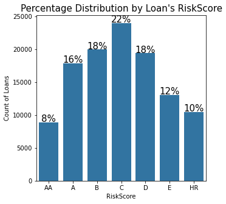

```python
## Now, Lets graph the RiskScore for the loans
RiskScore_order = ['AA','A','B','C','D','E','HR']

plt.figure(figsize=[5,5])
plt.title("Percentage Distribution by Loan's RiskScore",fontsize=15 )
sb.countplot(data=df, x=df.RiskScore,color=sb.color_palette()[0], order=RiskScore_order);
plt.ylabel('Count of Loans');

value_counts = df.RiskScore.value_counts()
total = value_counts.values.sum()
for i in range(len(RiskScore_order)):
    idx = RiskScore_order[i]
    count = value_counts.get(idx)

    pct = str(math.ceil((count * 100)/total)) + "%"
    y = count + 500
    plt.text(i, y, pct, ha='center', va='center', fontsize=15)
print()
```

#### Notes

- This graph shows that the dataset contains Loans with RiskScore from 'AA' to 'HR'
- So, looks like the loans has more 'C' RiskScore and only 8% of 'AA' RiskScore

### LoanStatus

Lets see status of the loans across all the 100K+ listings.

```
Good Loan = 94528 (84%)
 Bad Loan = 19278 (17%)
```

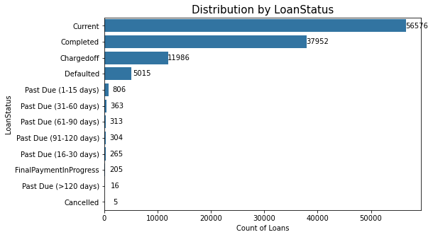

```python
## Lets see the Good and, (Potentially) Bad Loan

## Good Category Loan values
good_cat = ['Current', 'Completed']

good_loan = bad_loan = 0

## Plot
plt.figure(figsize=[8,5])
plt.title("Distribution by LoanStatus",fontsize=15 )
value_counts = df.LoanStatus.value_counts()
sb.countplot(data=df, y=df.LoanStatus, color=sb.color_palette()[0], order=value_counts.index);
plt.xlabel("Count of Loans")

#print(value_counts)
total = value_counts.values.sum()
for i in range(len(value_counts)):
    #idx = value_counts[i]
    count = value_counts[i]
    if value_counts.index[i] in good_cat:
        good_loan += count
    else:
        bad_loan += count

    #print(ListingCategory_Alpha[i], idx)
    #pct = str(math.ceil((count * 100)/total)) + "%"
    x = count + 2000
    plt.text(x, i,  count, ha='center', va='center', fontsize=10)


## Print Summary
good_loan_pct = math.ceil((good_loan * 100)/total)
bad_loan_pct = math.ceil((bad_loan * 100)/total)

print()


print("Good Loan = " + str(good_loan) + " (" + str(good_loan_pct) + "%)")
print(" Bad Loan = " + str(bad_loan)  + " (" + str(bad_loan_pct)  + "%)")

print()
```

#### Notes

- So from the output and graph it looks like Prosper loans (on an average) have been performing well.
- Good Loan were 84% and, (potentially) Bad loans were only 17%

So this indicates that Prosper is managing the Loan process very well.

### ListingCategory

Lets find the popular loan categories.

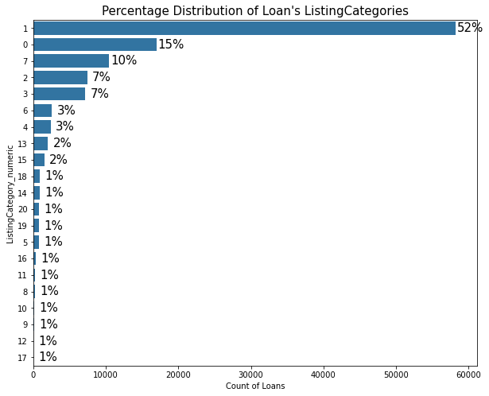

```python
## Lets rename the field
df.rename(columns={'ListingCategory (numeric)' : 'ListingCategory_numeric'},inplace=True)

## Do value_counts()
value_counts = df.ListingCategory_numeric.value_counts()

## From the Feature Definition file, we map the numbers to Alpha

ListingCategory_Alpha = [
    'Not Available','Debt Consolidation','Home Improvement','Business',
    'Personal Loan', 'Student Use', 'Auto', 'Other',
    'Baby&Adoption', 'Boat', 'Cosmetic Procedure','Engagement Ring',
    'Green Loans', 'Household Expenses', 'Large Purchases', 'Medical/Dental',
    'Motorcycle', 'RV','Taxes','Vacation','Wedding Loans'
    ]

cat_ordered = [ListingCategory_Alpha[idx] for idx in value_counts.index]
#print(cat_ordered)
#print(value_counts.index)
#df = df.rename(columns={'LstingCategory (numeric)':'ListingCategory_numeric})
plt.figure(figsize=[10,8])
plt.title("Percentage Distribution of Loan's ListingCategories",fontsize=15 )
sb.countplot(data=df, y=df.ListingCategory_numeric, color=sb.color_palette()[0], order=value_counts.index);
plt.xlabel("Count of Loans")
#plt.yticks(ticks=[0,1,2,3,4,5,6,7,8,9,10,11,12,13,14,15,16,17,18,19,20],labels=ListingCategory_Alpha)


#value_counts = df.ListingCategory_numeric.value_counts()
#print(value_counts)
ylabels = []
total = value_counts.values.sum()
#for i in (value_counts.index):
for i in range(len(value_counts)):
    #idx = value_counts[i]
    idx  = value_counts.index[i]
    count = value_counts.get(idx)
    ylabels.append(ListingCategory_Alpha[idx])

    #print(ListingCategory_Alpha[i], idx)
    pct = str(math.ceil((count * 100)/total)) + "%"
    x = count + 2000
    plt.text(x, i,  pct, ha='center', va='center', fontsize=15)

#print(ylabels)
#print(value_counts.index)
#plt.yticks(ticks=value_counts.index, labels=ylabels)


print()
```

#### Notes

- Looks like more than 50% of loans are for Debt consolidation.

### Term

Loan Term distribution

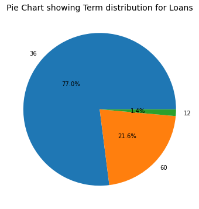

```python
#Using matplotlib
pie, ax = plt.subplots(figsize=[10,6])
value_counts = df.Term.value_counts()

labels = value_counts.index
plt.pie(x=value_counts.values, autopct="%.1f%%", labels=labels, pctdistance=0.5)
plt.title("Pie Chart showing Term distribution for Loans", fontsize=14);
#pie.savefig("DeliveryPieChart.png")
```

#### Notes

- About 77% of Loans made have a Term of 36 months and only 1.4% of loans made have 12 months.

### LoanOriginalAmount and EstimatedReturn

Since the EstimatedReturn is valid after July 2009, lets update our dataframe to only consider rows after July 2009

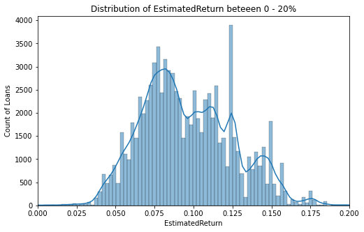

```python
# zoom in on histogram
plt.figure(figsize = [8,5])
sb.histplot(df2009.EstimatedReturn, kde = True, bins = 200)

plt.xlim(0, .2)

#plt.xlabel('Estimated Return 0')
plt.ylabel('Count of Loans');
plt.title('Distribution of EstimatedReturn beteeen 0 - 20%' );
```

## *Evaluating the Borrower data =>*

### Recommendations

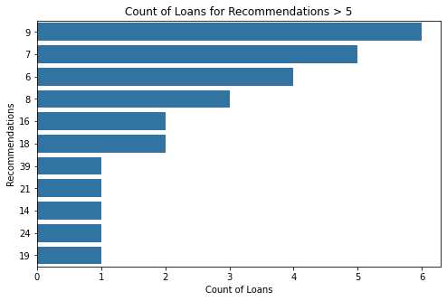

```python
df_rec5plus = df[df.Recommendations > 5]
#print (len(df_rec5plus))
value_counts = df_rec5plus.Recommendations.value_counts()

plt.figure(figsize = [8,5])
sb.countplot(data = df_rec5plus, y = df_rec5plus.Recommendations, color = sb.color_palette()[0], order=value_counts.index);
plt.xlabel('Count of Loans')
plt.title('Count of Loans for Recommendations > 5' );
```

#### Notes

- Interesting that there is less number of loans having higher recommendations.

### BorrowerState, EmploymentStatus, IncomeRange, CreditScoreRangeLower, Recommendations, TotalProsperLoans

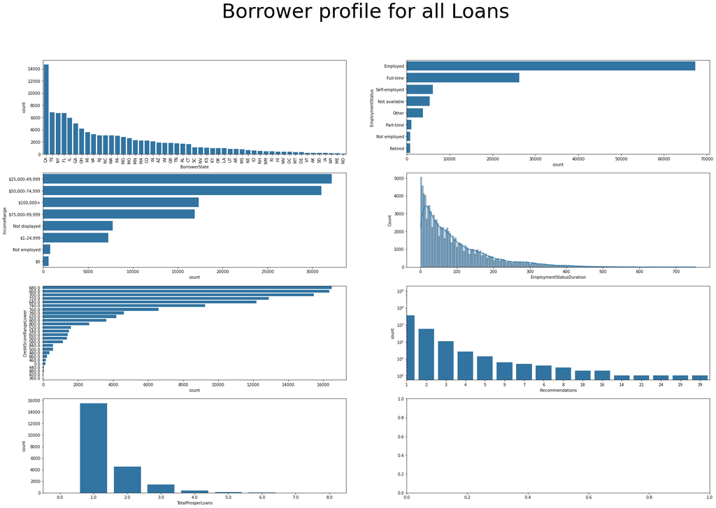

```python
## Subplots.

fig,((ax11,ax12),(ax21,ax22),(ax31,ax32),(ax41,ax42))= plt.subplots(nrows=4,ncols=2)
fig.set_size_inches(30,20)
fig.suptitle('Borrower profile for all Loans',size=50);
## 1. BorrowerState
value_counts = df.BorrowerState.value_counts()
sb.countplot(data = df, x= df.BorrowerState, color = sb.color_palette()[0], ax=ax11, order=value_counts.index);

## 2. EmploymentStatus
value_counts = df.EmploymentStatus.value_counts()
sb.countplot(data = df, y= df.EmploymentStatus, color = sb.color_palette()[0], ax=ax12,order=value_counts.index);
sb.histplot(data = df, x= df.EmploymentStatusDuration, kde = True, bins = 200, color = sb.color_palette()[0], ax=ax22);


## 3. IncomeRange
value_counts = df.IncomeRange.value_counts()
plt.setp(ax11.get_xticklabels(), rotation=90)
sb.countplot(data = df, y= df.IncomeRange, color = sb.color_palette()[0], ax=ax21, order=value_counts.index);


## 4. CreditScoreRangeLower
value_counts = df.CreditScoreRangeLower.value_counts()
sb.countplot(data = df, y= df.CreditScoreRangeLower, color = sb.color_palette()[0], ax=ax31,order=value_counts.index);



## 5. Recommendations
value_counts = df.Recommendations.value_counts()
sb.countplot(data = df, x= df.Recommendations, color = sb.color_palette()[0], ax=ax32,order=value_counts.index);
ax32.set_xlim(xmin = 1)
ax32.set_yscale("log")


## 6. TotalProsperLoans
sb.countplot(data = df, x= df.TotalProsperLoans, color = sb.color_palette()[0], ax=ax41);
df_p = df[df.TotalProsperLoans != 0]
#len(df_p)
#sb.countplot(data = df, x= df.TotalInquiries, color = sb.color_palette()[0], ax=ax42);
```

## Discuss the distribution(s) of your variable(s) of interest. Were there any unusual points? Did you need to perform any transformations?

> ListingCreationDate, ListingCategory, LoanOriginalAmount, EstimatedReturn, LoanStatus, Term, CreditGrade, IncomeRange, BorrowerAPR, BorrowerRate, BorrowerState, Occupation, Recommendations, ProsperScore,LenderYield variables were as expected except for the unusal distributions as mentioned below.

## Of the features you investigated, were there any unusual distributions? Did you perform any operations on the data to tidy, adjust, or change the form of the data? If so, why did you do this?

- The 'ListingCreationDate - Distribution by Year and Month' shows a deep drop in count for Year 2009. Upon further reviewing the variable definitions, we noticed significance to 2009 and the month of July in regards to EstimatedReturn. So we created 'df2009' dataframe to study the 'EstimatedReturns' for Loans after July 2009
- The 'RiskScore' for the Loan was developed by merging 'CreditGrade' and 'ProsperRating(Alpha)', during the process we discovered about 131 rows where both the values were NA. So we updated the dataframe df (line 10) to ignore these rows.
- About 27 rows seems to have greater number of recommendations than normal. Hence we tried to see if the borrower had good 'CreditScoreRangeLower'or 'IincomeRange' and, both these did not offer conclusive evidence for this. Further analysis could be done to narrow down the reason for this.
- 'EmploymentStatusDuration' shows the 700+ months of employment, which does not appear to be accurate So we will drop it from further using this field.

# Bivariate Exploration

Lets explore the graphs for qualtative and qualitative vars using the various Bivariant graphs

### 1a. Pair Plot

Pair Plot of quantative variables

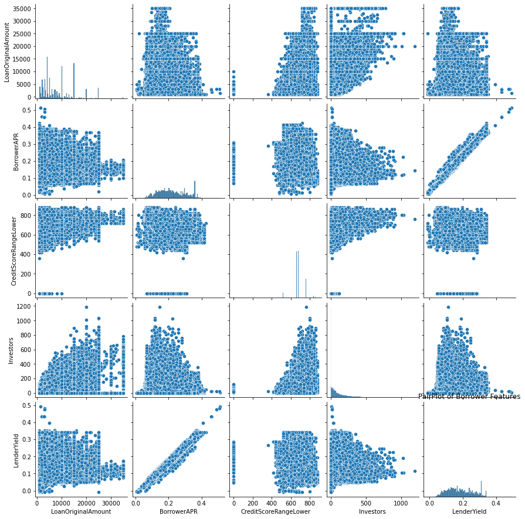

```python
g=sb.pairplot(data=df, vars=quan_vars);
plt.title('PairPlot of Borrower Features');
plt.show()
print()
```

#### Notes

These PairPlot shows

- Positive correlation between 'BorrowerAPR' with 'LenderYield'

### 1b. Heat Map

Heat Map of quantative variables showing correlation values

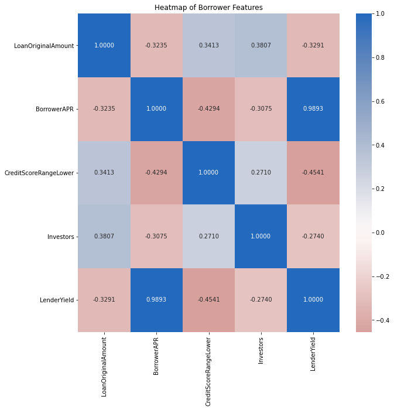

```python
plt.figure(figsize = [10, 10])
sb.heatmap(df[quan_vars].corr(), annot = True, fmt = '.4f',cmap = 'vlag_r', center = 0);
plt.title('Heatmap of Borrower Features');
```

#### Notes

These PairPlot and HeatMap shows the

- Positive correlation between 'BorrowerAPR' with 'LenderYield'
- Slightly Positive correlation with 'CreditScoreRangeLower' with 'Investors'
- Negative correlation between 'CreditScoreRangeLower' and 'BorrowerAPR'
- Negative correlation between 'CreditScoreRangeLower' and 'LenderYield'

## 2. Violin Plot

Violin Plot for Quantative variables.

### LoanOriginalAmount with Borrower IncomeRange

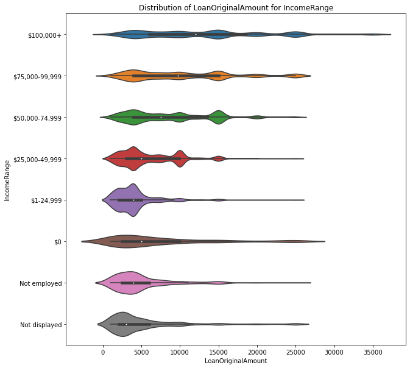

```python
value_counts = df.IncomeRange.value_counts()
#print(list(value_counts.index))
IncomeRange_order = ['$100,000+','$75,000-99,999', '$50,000-74,999', '$25,000-49,999','$1-24,999', '$0', 'Not employed', 'Not displayed']

df.LoanOriginalAmount.describe()


## ViolinPlot

plt.figure(figsize=[10,10])
sb.violinplot(data=df, x=df.LoanOriginalAmount, y=df.IncomeRange, order=IncomeRange_order);
plt.title("Distribution of LoanOriginalAmount for IncomeRange");
```

### 3. Box Plot

Studying Investors to Loan-RiskScore

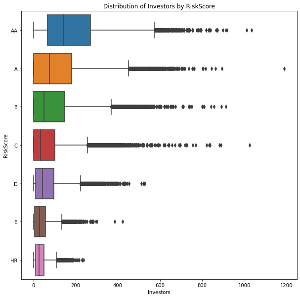

```python
## Boxplot.

plt.figure(figsize=[10,10])
sb.boxplot(data=df, x=df.Investors, y = df.RiskScore, order=RiskScore_order);#,hue=df.RiskScore;
plt.title("Distribution of Investors by RiskScore");
```

#### Notes

- The correlation is Loan RiskScore to Number of Investors is as expected i.e. a large number of investors are investing in Loans with high ratings 'AA', 'A', 'B', 'C'.
- All the RiskScore categories had outliers i.e > 1.5*IQR.
- 4 Loans had more than 1000 investors, on further analysis we note that the borrower from these Loans had good 'DebtToIncomeRatio' around 30% and had High IncomeRange (as expected)

## Talk about some of the relationships you observed in this part of the investigation. How did the feature(s) of interest vary with other features in the dataset?

- The HeatMap clearly showed the relationship between BorrowerAPR, LenderYeild, CreditScoreRangeLower, and Investors (please see HeatMap Note)
- The interest from Investors on Loan with RiskScore ('AA', - 'HR')

## Did you observe any interesting relationships between the other features (not the main feature(s) of interest)?

- The ViolinPlot is interesting, it shows LoanOriginalAmount ranging from 1k-30k when IncomeRange is $0, 'Not employed' It will be interesting to further study this group of borrowers for their 'CreditScoreRangeLower', and other fields.

# Multivariate Exploration

## LoanOriginalAmount, LenderYield, Term

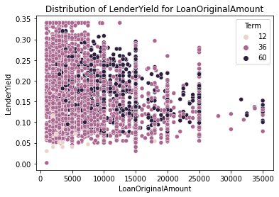

```python
df_5k = df.sample(n=5000)

sb.scatterplot(data=df_5k, x=df_5k.LoanOriginalAmount, y=df_5k.LenderYield, hue=df_5k.Term);
#sb.scatterplot(data=df, x=df.LoanOriginalAmount, y=df.LenderYield, hue=df.Term);
plt.title("Distribution of LenderYield for LoanOriginalAmount");
```

#### Notes

- This indicates that there is more loans at under 15k and have higher Yields. Also these loans typically are 36 month Term.

## RiskScore, LenderYield, CreditScoreRangeLower

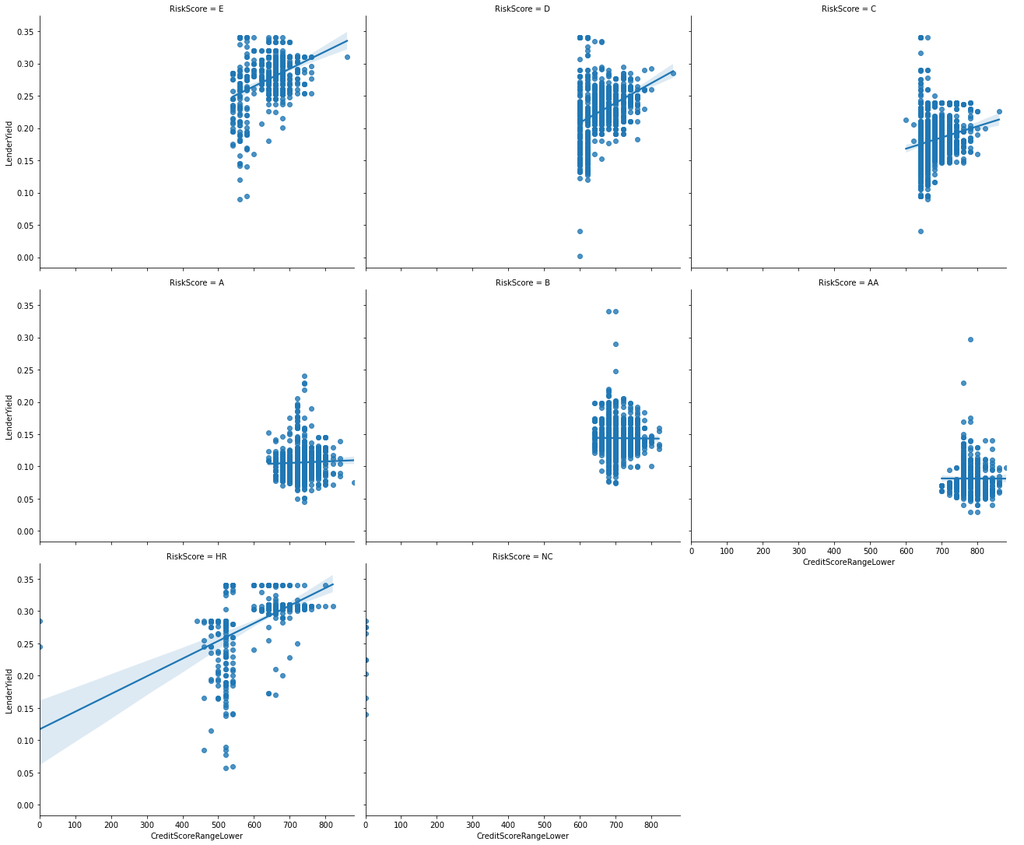

```python
g=sb.FacetGrid(data=df_5k, aspect=1.2, height=5, col='RiskScore', col_wrap=3)
g.map_dataframe(sb.regplot, y='LenderYield', x='CreditScoreRangeLower');#, x_jitter=0.04, scatter_kws={'alpha':0.1});
g.set_ylabels('LenderYield')
g.set_xlabels('CreditScoreRangeLower')
g.add_legend();
print()
```

#### Notes

This FacetGrid shows that the positive coorrlation of LenderYield when RiskScore is 'C', 'D', 'E' and when CreditScoreRangeLower is higher.

## Were there any interesting or surprising interactions between features?

- Seems like investors are teaming up on Higher RiskScore ('AA', 'A', 'B') but may have higher yeild when they lend to Loans in 'C', 'D', 'E'

## Loans with RiskScore 'C', 'D', 'E'

Final Visualization loans of with RiskScore 'C','D','E'

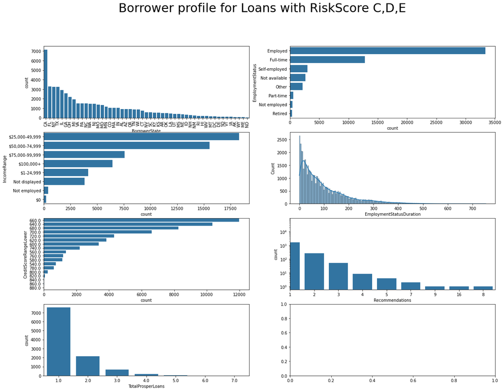

```python
df_cde = df[(df.RiskScore == 'C') | (df.RiskScore == 'D') | (df.RiskScore == 'E')]

## Subplots.
fig,((ax11,ax12),(ax21,ax22),(ax31,ax32),(ax41,ax42))= plt.subplots(nrows=4,ncols=2)
fig.set_size_inches(20,15)
fig.suptitle('Borrower profile for Loans with RiskScore C,D,E',size=30);

## 1. BorrowerState
value_counts = df_cde.BorrowerState.value_counts()
sb.countplot(data = df_cde, x= df_cde.BorrowerState, color = sb.color_palette()[0], ax=ax11, order=value_counts.index);

## 2. EmploymentStatus
value_counts = df_cde.EmploymentStatus.value_counts()
sb.countplot(data = df_cde, y= df_cde.EmploymentStatus, color = sb.color_palette()[0], ax=ax12,order=value_counts.index);
sb.histplot(data = df_cde, x= df_cde.EmploymentStatusDuration, kde = True, bins = 200, color = sb.color_palette()[0], ax=ax22);


## 3. IncomeRange
value_counts = df_cde.IncomeRange.value_counts()
plt.setp(ax11.get_xticklabels(), rotation=90)
sb.countplot(data = df_cde, y= df_cde.IncomeRange, color = sb.color_palette()[0], ax=ax21, order=value_counts.index);


## 4. CreditScoreRangeLower
value_counts = df_cde.CreditScoreRangeLower.value_counts()
sb.countplot(data = df_cde, y= df_cde.CreditScoreRangeLower, color = sb.color_palette()[0], ax=ax31,order=value_counts.index);



## 5. Recommendations
value_counts = df_cde.Recommendations.value_counts()
sb.countplot(data = df_cde, x= df_cde.Recommendations, color = sb.color_palette()[0], ax=ax32,order=value_counts.index);
ax32.set_xlim(xmin = 1)
ax32.set_yscale("log")


## 6. TotalProsperLoans
sb.countplot(data = df_cde, x= df_cde.TotalProsperLoans, color = sb.color_palette()[0], ax=ax41);
df_p = df_cde[df_cde.TotalProsperLoans != 0]
#len(df_p)
#sb.countplot(data = df, x= df.TotalInquiries, color = sb.color_palette()[0], ax=ax42);
```

#### Notes

- Loan with RiskScore 'C', 'D', 'E' seems to have Borrowers from 'CA', 'Employed', with IncomeRange $24,000 - $49,999 and have a CreditScore in range of 640-680 and many have at least 1 loan.

# Summary

So investigation through visualization reveals that for Higher LenderYield the Lender may focus on Loans having the following characterstics:

- Loans around 10k, with 36 Month Term. And additionally, when the RiskScore is 'C', 'D', 'E' and Borrower CreditScoreRangeLower is above 640+

These findings fulfills the Goal-> to understand the Loan characterstics that investors must consider to have higher returns.